# Self-Driving Car Engineer Nanodegree

## Project: Build a Traffic Sign Recognition Classifier

In this notebook, a template is provided for you to implement your functionality in stages which is required to successfully complete this project. If additional code is required that cannot be included in the notebook, be sure that the Python code is successfully imported and included in your submission, if necessary. Sections that begin with **'Implementation'** in the header indicate where you should begin your implementation for your project. Note that some sections of implementation are optional, and will be marked with **'Optional'** in the header.

In addition to implementing code, there will be questions that you must answer which relate to the project and your implementation. Each section where you will answer a question is preceded by a **'Question'** header. Carefully read each question and provide thorough answers in the following text boxes that begin with **'Answer:'**. Your project submission will be evaluated based on your answers to each of the questions and the implementation you provide.

> **Note:** Code and Markdown cells can be executed using the **Shift + Enter** keyboard shortcut. In addition, Markdown cells can be edited by typically double-clicking the cell to enter edit mode.

## Step 1: Dataset Exploration

Visualize the German Traffic Signs Dataset. This is open ended, some suggestions include: plotting traffic signs images, plotting the count of each sign, etc. Be creative!

The pickled data is a dictionary with 4 key/value pairs:

- features -> the images pixel values, (width, height, channels)
- labels -> the label of the traffic sign
- sizes -> the original width and height of the image, (width, height)
- coords -> coordinates of a bounding box around the sign in the image, (x1, y1, x2, y2). Based the original image (not the resized version).

```python
# Load functions

import os
os.listdir("/")
import pickle
import numpy as np
from sklearn.metrics import confusion_matrix
import tensorflow as tf
%matplotlib inline
import matplotlib.pyplot as plt
import matplotlib.gridspec as gridspec
from tqdm import tqdm
import random
from sklearn.utils import resample
from sklearn.preprocessing import LabelBinarizer
from sklearn.model_selection import train_test_split
from PIL import Image
#import cv2
from scipy import misc
from scipy import ndimage
import math

# Limit the amount of data to work with a docker container
docker_size_limit = 15000


# TODO: fill this in based on where you saved the training and testing data
training_file = 'train.p'
testing_file = 'test.p'
# Extract the training and test data with pickle
with open(training_file, mode='rb') as f:
    train = pickle.load(f)

with open(testing_file, mode='rb') as f:
    test = pickle.load(f)

with open(testing_file, mode='rb') as f:
    validation = pickle.load(f)


train_features, train_labels = train['features'], train['labels']
test_features, test_labels = test['features'], test['labels']
```

```python
np.unique(test_labels)
```

```
array([ 0,  1,  2,  3,  4,  5,  6,  7,  8,  9, 10, 11, 12, 13, 14, 15, 16,
       17, 18, 19, 20, 21, 22, 23, 24, 25, 26, 27, 28, 29, 30, 31, 32, 33,
       34, 35, 36, 37, 38, 39, 40, 41, 42], dtype=uint8)
```

```python
signname_map = np.genfromtxt('signnames.csv', skip_header=1, delimiter=',', usecols=(1,), unpack=True, dtype=str)


# Use the mapping array to print the SignName.
predictions = np.unique(test_labels)
predict_signNames = []
for id in predictions:
    predict_signNames.append(signname_map[int(id)])
print(predict_signNames)
```

[output not shown]

```python
### To start off let's do a basic data summary.

# TODO: number of training examples
n_train = 39209

# TODO: number of testing examples
n_test = 12630

# TODO: what's the shape of an image?
image_shape = (32,32)

# TODO: how many classes are in the dataset
n_classes = 43

print("Number of training examples =", n_train)
print("Number of testing examples =", n_test)
print("Image data shape =", image_shape)
print("Number of classes =", n_classes)
```

```
Number of training examples = 39209
Number of testing examples = 12630
Image data shape = (32, 32)
Number of classes = 43
```

```python
# Set flags for feature engineering.  This will prevent you from skipping an important step.
is_features_normal = False
is_labels_encod = False
```

```python
#Implement Min-Max scaling for greyscale image data
def normalize_greyscale(image_data):
    """
    Normalize the image data with Min-Max scaling to a range of [0.1, 0.9]
    :param image_data: The image data to be normalized
    :return: Normalized image data
    """
    # ToDo: Implement Min-Max scaling for greyscale image data
    a = 0.1
    b = 0.9
    greyscale_min = 0
    greyscale_max = 255
    return a + ( ( (image_data - greyscale_min)*(b - a) )/( greyscale_max - greyscale_min ) )

if not is_features_normal:
    train_features = normalize_greyscale(train_features)
    test_features = normalize_greyscale(test_features)
    is_features_normal = True

print('Tests Passed!')
```

```
Tests Passed!
```

```python
train_features, train_labels = resample(train_features, train_labels, n_samples=docker_size_limit)
```

```python
from sklearn.preprocessing import OneHotEncoder

def OHE_labels(Y_t,N_classes):
    OHC = OneHotEncoder()

    Y_ohc = OHC.fit(np.arange(N_classes).reshape(-1, 1))
    Y_labels = Y_ohc.transform(Y_t.reshape(-1, 1)).toarray()

    return Y_labels


train_labels = OHE_labels(train_labels,43)
test_labels = OHE_labels(test_labels,43)
is_labels_encod = True
print('Labels One-Hot Encoded')
```

```
Labels One-Hot Encoded
```

```python
assert is_features_normal, 'You skipped the step to normalize the features'
assert is_labels_encod, 'You skipped the step to One-Hot Encode the labels'

# Get randomized datasets for training and validation
train_features, valid_features, train_labels, valid_labels = train_test_split(
    train_features,
    train_labels,
    test_size=0.05,
    random_state=0)

print('Training features and labels randomized and split.')
```

```
Training features and labels randomized and split.
```

```python
train_features = train_features.reshape(-1, 32*32*3)
```

```python
test_features = test_features.reshape(-1, 32*32*3)
```

```python
valid_features = valid_features.reshape(-1, 32*32*3)
```

```python
#Change to float32, so it can be multiplied against the features in TensorFlow, which are float32
train_labels = train_labels.astype(np.float32)
test_labels = test_labels.astype(np.float32)
train_features = train_features.astype(np.float32)
test_features = test_features.astype(np.float32)
valid_features = valid_features.astype(np.float32)
valid_labels = valid_labels.astype(np.float32)
```

```python
valid_features.shape, valid_labels.shape
```

```
((750, 3072), (750, 43))
```

```python
features_count = 32*32*3
labels_count = 43

#Set the features and labels tensors
features = tf.placeholder(tf.float32)
labels = tf.placeholder(tf.float32)

# Problem 2 - Set the weights and biases tensors
weights = tf.Variable(tf.truncated_normal((features_count, labels_count)))
biases = tf.Variable(tf.zeros(labels_count))
```

```python
#Test Cases
from tensorflow.python.ops.variables import Variable

assert features._op.name.startswith('Placeholder'), 'features must be a placeholder'
assert labels._op.name.startswith('Placeholder'), 'labels must be a placeholder'
assert isinstance(weights, Variable), 'weights must be a TensorFlow variable'
assert isinstance(biases, Variable), 'biases must be a TensorFlow variable'

assert features._shape == None or (\
    features._shape.dims[0].value is None and\
    features._shape.dims[1].value in [None, features_count]), 'The shape of features is incorrect'
assert labels._shape in [None, labels_count], 'The shape of labels is incorrect'
assert weights._variable._shape == (features_count, labels_count), 'The shape of weights is incorrect'
assert biases._variable._shape == (labels_count), 'The shape of biases is incorrect'

assert features._dtype == tf.float32, 'features must be type float32'
assert labels._dtype == tf.float32, 'labels must be type float32'
```

```python
# Feed dicts for training, validation, and test session#valid_feed_dict = {features: valid_features, labels: valid_labels}
test_feed_dict = {features: test_features, labels: test_labels}
train_feed_dict = {features: train_features, labels: train_labels}
valid_feed_dict = {features: valid_features, labels: valid_labels}

# Linear Function WX + b
logits = tf.matmul(features, weights) + biases

prediction = tf.nn.softmax(logits)

# Cross entropy

cross_entropy = tf.reduce_mean(-tf.reduce_sum(labels * tf.log(tf.clip_by_value(prediction,1e-10,1.0)),
                                              reduction_indices=[1]))


# Training loss
loss = tf.reduce_mean(cross_entropy)

# Create an operation that initializes all variables
init = tf.initialize_all_variables()
```

```python
# Test Cases
with tf.Session() as session:
    session.run(init)
    session.run(loss, feed_dict=train_feed_dict)
    session.run(loss, feed_dict=valid_feed_dict)
    session.run(loss, feed_dict=test_feed_dict)
    biases_data = session.run(biases)

assert not np.count_nonzero(biases_data), 'biases must be zeros'

print('Tests Passed!')
```

```
Tests Passed!
```

```python
# Determine if the predictions are correct
is_correct_prediction = tf.equal(tf.argmax(prediction, 1), tf.argmax(labels, 1))
# Calculate the accuracy of the predictions
accuracy = tf.reduce_mean(tf.cast(is_correct_prediction, tf.float32))

print('Accuracy function created.')
```

```
Accuracy function created.
```

```
Validation accuracy at 0.0533333346247673 Training accuracy at 0.043929822742938995
```

```
Validation accuracy at 0.25600001215934753 Training accuracy at 0.2762807011604309
```

```
Validation accuracy at 0.3813333213329315 Training accuracy at 0.4112982451915741
```

```
Validation accuracy at 0.4906666576862335 Training accuracy at 0.5063157677650452
```

```
Validation accuracy at 0.609333336353302 Training accuracy at 0.6216140389442444
```

```
Validation accuracy at 0.6439999938011169 Training accuracy at 0.6691228151321411
```

```
Validation accuracy at 0.656000018119812 Training accuracy at 0.6737543940544128
```

```
Validation accuracy at 0.6746666431427002 Training accuracy at 0.7050526142120361
```

```
Validation accuracy at 0.6946666836738586 Training accuracy at 0.7239999771118164
```

```
Validation accuracy at 0.7333333492279053 Training accuracy at 0.7594385743141174
```

```
Validation accuracy at 0.7506666779518127 Training accuracy at 0.7809824347496033
```

```
Validation accuracy at 0.7853333353996277 Training accuracy at 0.8079298138618469
```

```
Validation accuracy at 0.7773333191871643 Training accuracy at 0.8063157796859741
```

```
Validation accuracy at 0.7799999713897705 Training accuracy at 0.8181052803993225
```

```
Validation accuracy at 0.8106666803359985 Training accuracy at 0.8410526514053345
```

```
Validation accuracy at 0.8253333568572998 Training accuracy at 0.8584561347961426
```

```
Validation accuracy at 0.8173333406448364 Training accuracy at 0.8599298000335693
```

```
Validation accuracy at 0.8226666450500488 Training accuracy at 0.8663157820701599
```

```
Validation accuracy at 0.8320000171661377 Training accuracy at 0.874666690826416
```

```
Validation accuracy at 0.8453333377838135 Training accuracy at 0.8872280716896057
```

```
Validation accuracy at 0.8546666502952576 Training accuracy at 0.8924912214279175
```

```
Validation accuracy at 0.8506666421890259 Training accuracy at 0.8913684487342834
```

```
Validation accuracy at 0.8546666502952576 Training accuracy at 0.8952982425689697
```

```
Validation accuracy at 0.8666666746139526 Training accuracy at 0.902526319026947
```

```
Validation accuracy at 0.8600000143051147 Training accuracy at 0.9004912376403809
```

```
Validation accuracy at 0.8479999899864197 Training accuracy at 0.8878596425056458
```

```
Validation accuracy at 0.8666666746139526 Training accuracy at 0.9108070135116577
```

```
Validation accuracy at 0.8600000143051147 Training accuracy at 0.9075789451599121
```

```
Validation accuracy at 0.8613333106040955 Training accuracy at 0.9075789451599121
```

```
Validation accuracy at 0.8693333268165588 Training accuracy at 0.9157192707061768
```

```
Validation accuracy at 0.8640000224113464 Training accuracy at 0.9114385843276978
```

```
Validation accuracy at 0.8733333349227905 Training accuracy at 0.9179649353027344
```

```
Validation accuracy at 0.8640000224113464 Training accuracy at 0.9176140427589417
```

```
Validation accuracy at 0.8706666827201843 Training accuracy at 0.9143157601356506
```

```
Validation accuracy at 0.8706666827201843 Training accuracy at 0.92182457447052
```

```
Validation accuracy at 0.871999979019165 Training accuracy at 0.9227368235588074
```

```
Validation accuracy at 0.871999979019165 Training accuracy at 0.9246315956115723
```

```
Validation accuracy at 0.8706666827201843 Training accuracy at 0.9197192788124084
```

```
Validation accuracy at 0.8679999709129333 Training accuracy at 0.9266666769981384
```

```
Validation accuracy at 0.874666690826416 Training accuracy at 0.9241403341293335
```

```
Validation accuracy at 0.871999979019165 Training accuracy at 0.9282104969024658
```

```
Validation accuracy at 0.8773333430290222 Training accuracy at 0.9312280416488647
```

```
Validation accuracy at 0.8826666474342346 Training accuracy at 0.9415438771247864
```

```
Validation accuracy at 0.8893333077430725 Training accuracy at 0.9412631392478943
```

```
Validation accuracy at 0.8880000114440918 Training accuracy at 0.9434385895729065
```

```
Validation accuracy at 0.8813333511352539 Training accuracy at 0.9432982206344604
```

```
Validation accuracy at 0.8840000033378601 Training accuracy at 0.9364210367202759
```

```
Validation accuracy at 0.8813333511352539 Training accuracy at 0.9332631826400757
```

```
Validation accuracy at 0.8813333511352539 Training accuracy at 0.9350877404212952
```

```
Validation accuracy at 0.8880000114440918 Training accuracy at 0.9378947615623474
```

```
Validation accuracy at 0.8893333077430725 Training accuracy at 0.9457544088363647
```

```
Validation accuracy at 0.8946666717529297 Training accuracy at 0.9475789666175842
```

```
Validation accuracy at 0.8933333158493042 Training accuracy at 0.9474385976791382
```

```
Validation accuracy at 0.8866666555404663 Training accuracy at 0.9399999976158142
```

```
Validation accuracy at 0.8853333592414856 Training accuracy at 0.9420350790023804
```

```
Validation accuracy at 0.8973333239555359 Training accuracy at 0.9513683915138245
```

```
Validation accuracy at 0.8960000276565552 Training accuracy at 0.9515789747238159
```

```
Validation accuracy at 0.8986666798591614 Training accuracy at 0.9531227946281433
```

```
Validation accuracy at 0.8986666798591614 Training accuracy at 0.95396488904953
```

```
Validation accuracy at 0.8999999761581421 Training accuracy at 0.9547368288040161
```

```
Validation accuracy at 0.8986666798591614 Training accuracy at 0.9544561505317688
```

```
Validation accuracy at 0.8986666798591614 Training accuracy at 0.9547368288040161
```

```
Validation accuracy at 0.8986666798591614 Training accuracy at 0.9557894468307495
```

```
Validation accuracy at 0.8946666717529297 Training accuracy at 0.9520000219345093
```

```
Validation accuracy at 0.9039999842643738 Training accuracy at 0.9574034810066223
```

```
Validation accuracy at 0.9013333320617676 Training accuracy at 0.9559298157691956
```

```
Validation accuracy at 0.9039999842643738 Training accuracy at 0.9561403393745422
```

```
Validation accuracy at 0.9026666879653931 Training accuracy at 0.9560701847076416
```

```
Validation accuracy at 0.8999999761581421 Training accuracy at 0.9567719101905823
```

```
Validation accuracy at 0.9039999842643738 Training accuracy at 0.9578947424888611
```

```
Validation accuracy at 0.9039999842643738 Training accuracy at 0.9581754207611084
```

```
Validation accuracy at 0.8986666798591614 Training accuracy at 0.9578245878219604
```

```
Validation accuracy at 0.8986666798591614 Training accuracy at 0.9583157896995544
```

```
Validation accuracy at 0.8986666798591614 Training accuracy at 0.9585964679718018
```

```
Validation accuracy at 0.8986666798591614 Training accuracy at 0.9586666822433472
```

```
Validation accuracy at 0.8986666798591614 Training accuracy at 0.9589473605155945
```

```
Validation accuracy at 0.8999999761581421 Training accuracy at 0.9591578841209412
```

```
Validation accuracy at 0.8999999761581421 Training accuracy at 0.9595087766647339
```

```
Validation accuracy at 0.8999999761581421 Training accuracy at 0.9595789313316345
```

```
Validation accuracy at 0.8999999761581421 Training accuracy at 0.9596491456031799
```

```
Validation accuracy at 0.8986666798591614 Training accuracy at 0.9599298238754272
```

```
Validation accuracy at 0.8986666798591614 Training accuracy at 0.9603508710861206
```

```
Validation accuracy at 0.8999999761581421 Training accuracy at 0.96091228723526
```

```
Validation accuracy at 0.9013333320617676 Training accuracy at 0.9613333344459534
```

```
Validation accuracy at 0.9013333320617676 Training accuracy at 0.9616140127182007
```

```
Validation accuracy at 0.9013333320617676 Training accuracy at 0.962035059928894
```

```
Validation accuracy at 0.9013333320617676 Training accuracy at 0.962035059928894
```

```
Validation accuracy at 0.9026666879653931 Training accuracy at 0.9623859524726868
```

```
Validation accuracy at 0.8999999761581421 Training accuracy at 0.9623859524726868
```

```
Validation accuracy at 0.8999999761581421 Training accuracy at 0.9625263214111328
```

```
Validation accuracy at 0.8999999761581421 Training accuracy at 0.9627368450164795
```

```
Validation accuracy at 0.8999999761581421 Training accuracy at 0.9628069996833801
```

```
Validation accuracy at 0.9013333320617676 Training accuracy at 0.9630877375602722
```

```
Validation accuracy at 0.9013333320617676 Training accuracy at 0.9632280468940735
```

```
Validation accuracy at 0.9013333320617676 Training accuracy at 0.9635789394378662
```

```
Validation accuracy at 0.9013333320617676 Training accuracy at 0.9635789394378662
```

```
Validation accuracy at 0.9013333320617676 Training accuracy at 0.9639298319816589
```

```
Validation accuracy at 0.9013333320617676 Training accuracy at 0.964070200920105
```

```
Validation accuracy at 0.9013333320617676 Training accuracy at 0.9642105102539062
```

```
Validation accuracy at 0.9013333320617676 Training accuracy at 0.9642807245254517
```

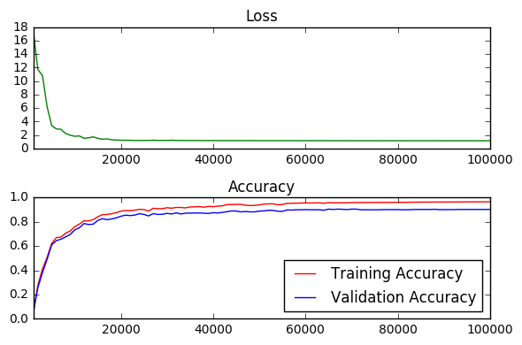

```python
epochs = 100

batch_size = 20
learning_rate = .24
### DON'T MODIFY ANYTHING BELOW ###
# Gradient Descent
optimizer = tf.train.GradientDescentOptimizer(learning_rate).minimize(loss)

# The accuracy measured against the validation set
validation_accuracy = 0.0

# Measurements use for graphing loss and accuracy
log_batch_step = 1000
batches = []
loss_batch = []
train_acc_batch = []
valid_acc_batch = []

with tf.Session() as session:
    session.run(init)
    batch_count = int(math.ceil(len(train_features)/batch_size))

    for epoch_i in range(epochs):

        # Progress bar
        batches_pbar = tqdm(range(batch_count), desc='Epoch {:>2}/{}'.format(epoch_i+1, epochs), unit='batches')

        # The training cycle
        for batch_i in batches_pbar:
            # Get a batch of training features and labels
            batch_start = batch_i*batch_size
            batch_features = train_features[batch_start:batch_start + batch_size]
            batch_labels = train_labels[batch_start:batch_start + batch_size]

            # Run optimizer and get loss
            _, l = session.run(
                [optimizer, loss],
                feed_dict={features: batch_features, labels: batch_labels})

            # Log every 50 batches
            if not batch_i % log_batch_step:
                # Calculate Training and Validation accuracy
                training_accuracy = session.run(accuracy, feed_dict=train_feed_dict)
                validation_accuracy = session.run(accuracy, feed_dict=valid_feed_dict)

                # Log batches
                previous_batch = batches[-1] if batches else 0
                batches.append(log_batch_step + previous_batch)
                loss_batch.append(l)
                train_acc_batch.append(training_accuracy)
                valid_acc_batch.append(validation_accuracy)
        print('Validation accuracy at {}'.format(validation_accuracy),'Training accuracy at {}'.format(training_accuracy) )
        # Check accuracy against Validation data
        validation_accuracy = session.run(accuracy, feed_dict=valid_feed_dict)

loss_plot = plt.subplot(211)
loss_plot.set_title('Loss')
loss_plot.plot(batches, loss_batch, 'g')
loss_plot.set_xlim([batches[0], batches[-1]])
acc_plot = plt.subplot(212)
acc_plot.set_title('Accuracy')
acc_plot.plot(batches, train_acc_batch, 'r', label='Training Accuracy')
acc_plot.plot(batches, valid_acc_batch, 'b', label='Validation Accuracy')
acc_plot.set_ylim([0, 1.0])
acc_plot.set_xlim([batches[0], batches[-1]])
acc_plot.legend(loc=4)
plt.tight_layout()
plt.show()
```

```python
test_features = test_features.reshape(-1, 32, 32,3)
```

[figure not shown]

```python
img=Image.open('stop.png')
img_rgb = img.convert('RGB')
img_rgb.thumbnail((32,32), Image.ANTIALIAS)
X_tr = np.reshape(img_rgb, (1, 32, 32, 3))
plt.imshow(img_rgb)
```

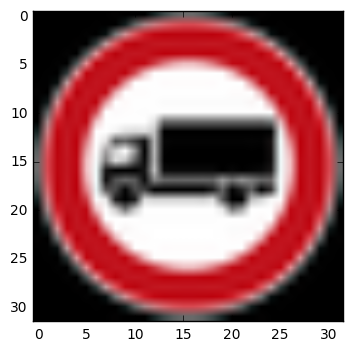

```python
img=Image.open('trump.png')
img_rgb = img.convert('RGB')
img_rgb.thumbnail((32,32), Image.ANTIALIAS)
X_tr2 = np.reshape(img_rgb, (1, 32, 32, 3))
plt.imshow(img_rgb)
```

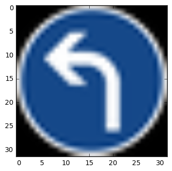

```python
img=Image.open('turnleft.png')
img_rgb = img.convert('RGB')
img_rgb.thumbnail((32,32), Image.ANTIALIAS)
X_tr3 = np.reshape(img_rgb, (1, 32, 32, 3))
plt.imshow(img_rgb)
```

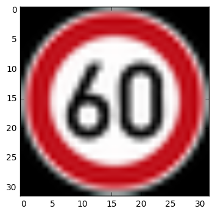

```python
img=Image.open('60kmph.png')
img_rgb = img.convert('RGB')
img_rgb.thumbnail((32,32), Image.ANTIALIAS)
X_tr4 = np.reshape(img_rgb, (1, 32, 32, 3))
plt.imshow(img_rgb)
```

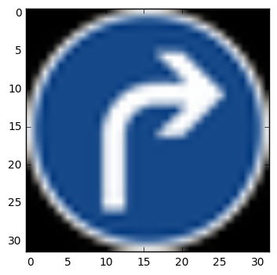

```python
img=Image.open('turnright.png')
img_rgb = img.convert('RGB')
img_rgb.thumbnail((32,32), Image.ANTIALIAS)
X_tr5 = np.reshape(img_rgb, (1, 32, 32, 3))
plt.imshow(img_rgb)
```

```python
X_tr5.shape
```

```
(1, 32, 32, 3)
```

```python
labels = test_features
```

```python
type(test_features)
```

```
numpy.ndarray
```

```python
y_pred = tf.nn.softmax(logits)
```

```python
newdata = X_tr
newdata.shape
```

```
(1, 32, 32, 3)
```

```python
newdata = np.vstack([newdata, X_tr2])
newdata = np.vstack([newdata, X_tr3])
newdata = np.vstack([newdata, X_tr4])
newdata = np.vstack([newdata, X_tr5])
newdata.shape
```

```
(5, 32, 32, 3)
```

```python
newdata = newdata.reshape(-1, 32*32*3)
```

```python
type(features)
```

```
tensorflow.python.framework.ops.Tensor
```

```python
type(newdata)
```

```
numpy.ndarray
```

```python
# Add an op to initialize the variables.
init_op = tf.initialize_all_variables()
topFive=tf.nn.top_k(prediction, k=5, sorted=True, name=None)
topFive
```

```
TopKV2(values=<tf.Tensor 'TopKV2:0' shape=(?, 5) dtype=float32>, indices=<tf.Tensor 'TopKV2:1' shape=(?, 5) dtype=int32>)
```

```python
features
```

```
<tf.Tensor 'Placeholder:0' shape=<unknown> dtype=float32>
```

```python
# Add an op to initialize the variables.
init_op = tf.initialize_all_variables()
topFive=tf.nn.top_k(prediction, k=5, sorted=True, name=None)
top_k_feed_dict = {features: newdata}
# Run the tf.nn.top_k operation in the session

with tf.Session() as session:
    # Run the init operation.
    session.run(init_op)
    print(session.run(topFive, feed_dict = top_k_feed_dict))
```

```
TopKV2(values=array([[ 1.,  0.,  0.,  0.,  0.],
       [ 1.,  0.,  0.,  0.,  0.],
       [ 1.,  0.,  0.,  0.,  0.],
       [ 1.,  0.,  0.,  0.,  0.],
       [ 1.,  0.,  0.,  0.,  0.]], dtype=float32), indices=array([[23,  0,  1,  2,  3],
       [28,  0,  1,  2,  3],
       [ 7,  0,  1,  2,  3],
       [28,  0,  1,  2,  3],
       [16,  0,  1,  2,  3]], dtype=int32))
```

## Step 2: Design and Test a Model Architecture

Design and implement a deep learning model that learns to recognize traffic signs. Train and test your model on the [German Traffic Sign Dataset](http://benchmark.ini.rub.de/?section=gtsrb&subsection=dataset).

There are various aspects to consider when thinking about this problem:

- Your model can be derived from a deep feedforward net or a deep convolutional network.
- Play around preprocessing techniques (normalization, rgb to grayscale, etc)
- Number of examples per label (some have more than others).
- Generate fake data.

Here is an example of a [published baseline model on this problem](http://yann.lecun.com/exdb/publis/pdf/sermanet-ijcnn-11.pdf). It's not required to be familiar with the approach used in the paper but, it's good practice to try to read papers like these.

### Implementation

Use the code cell (or multiple code cells, if necessary) to implement the first step of your project. Once you have completed your implementation and are satisfied with the results, be sure to thoroughly answer the questions that follow.

### Question 1

*Describe the techniques used to preprocess the data.*

### Question 2

*Describe how you set up the training, validation and testing data for your model. If you generated additional data, why?*

### Question 3

*What does your final architecture look like? (Type of model, layers, sizes, connectivity, etc.) For reference on how to build a deep neural network using TensorFlow, see Deep Neural Network in TensorFlow from the classroom.*

### Question 4

*How did you train your model? (Type of optimizer, batch size, epochs, hyperparameters, etc.)*

### Question 5

*What approach did you take in coming up with a solution to this problem?*

## Step 3: Test a Model on New Images

Take several pictures of traffic signs that you find on the web or around you (at least five), and run them through your classifier on your computer to produce example results. The classifier might not recognize some local signs but it could prove interesting nonetheless.

You may find `signnames.csv` useful as it contains mappings from the class id (integer) to the actual sign name.

### Implementation

Use the code cell (or multiple code cells, if necessary) to implement the first step of your project. Once you have completed your implementation and are satisfied with the results, be sure to thoroughly answer the questions that follow.

### Question 6

*Choose five candidate images of traffic signs and provide them in the report. Are there any particular qualities of the image(s) that might make classification difficult? It would be helpful to plot the images in the notebook.*

### Question 7

*Is your model able to perform equally well on captured pictures or a live camera stream when compared to testing on the dataset?*

### Question 8

*Use the model's softmax probabilities to visualize the **certainty** of its predictions, [`tf.nn.top_k`](https://www.tensorflow.org/versions/r0.11/api_docs/python/nn.html#top_k) could prove helpful here. Which predictions is the model certain of? Uncertain? If the model was incorrect in its initial prediction, does the correct prediction appear in the top k? (k should be 5 at most)*

### Question 9

*If necessary, provide documentation for how an interface was built for your model to load and classify newly-acquired images.*